# Google_App_Store_Rating_0_16115900_1773381940

**Google App Store Rating**

**Q1. Import required libraries and read the dataset.**

```python
import numpy as np
import pandas as pd
import matplotlib.pyplot as plt
import seaborn as sns
df = pd.read_csv("/content/Apps_data.csv")
df
```

|  | App | Category | Rating | Reviews | Size | Installs | Type | Price | Content Rating | Genres | Last Updated | Current Ver | Android Ver |
| --- | --- | --- | --- | --- | --- | --- | --- | --- | --- | --- | --- | --- | --- |
| 0 | Photo Editor & Candy Camera & Grid & ScrapBook | ART_AND_DESIGN | 4.1 | 159 | 19M | 10,000+ | Free | 0 | Everyone | Art & Design | January 7, 2018 | 1.0.0 | 4.0.3 and up |
| 1 | Coloring book moana | ART_AND_DESIGN | 3.9 | 967 | 14M | 500,000+ | Free | 0 | Everyone | Art & Design;Pretend Play | January 15, 2018 | 2.0.0 | 4.0.3 and up |
| 2 | U Launcher Lite – FREE Live Cool Themes, Hide ... | ART_AND_DESIGN | 4.7 | 87510 | 8.7M | 5,000,000+ | Free | 0 | Everyone | Art & Design | August 1, 2018 | 1.2.4 | 4.0.3 and up |
| 3 | Sketch - Draw & Paint | ART_AND_DESIGN | 4.5 | 215644 | 25M | 50,000,000+ | Free | 0 | Teen | Art & Design | June 8, 2018 | Varies with device | 4.2 and up |
| 4 | Pixel Draw - Number Art Coloring Book | ART_AND_DESIGN | 4.3 | 967 | 2.8M | 100,000+ | Free | 0 | Everyone | Art & Design;Creativity | June 20, 2018 | 1.1 | 4.4 and up |
| ... | ... | ... | ... | ... | ... | ... | ... | ... | ... | ... | ... | ... | ... |
| 10836 | Sya9a Maroc - FR | FAMILY | 4.5 | 38 | 53M | 5,000+ | Free | 0 | Everyone | Education | July 25, 2017 | 1.48 | 4.1 and up |
| 10837 | Fr. Mike Schmitz Audio Teachings | FAMILY | 5.0 | 4 | 3.6M | 100+ | Free | 0 | Everyone | Education | July 6, 2018 | 1.0 | 4.1 and up |
| 10838 | Parkinson Exercices FR | MEDICAL | NaN | 3 | 9.5M | 1,000+ | Free | 0 | Everyone | Medical | January 20, 2017 | 1.0 | 2.2 and up |
| 10839 | The SCP Foundation DB fr nn5n | BOOKS_AND_REFERENCE | 4.5 | 114 | Varies with device | 1,000+ | Free | 0 | Mature 17+ | Books & Reference | January 19, 2015 | Varies with device | Varies with device |
| 10840 | iHoroscope - 2018 Daily Horoscope & Astrology | LIFESTYLE | 4.5 | 398307 | 19M | 10,000,000+ | Free | 0 | Everyone | Lifestyle | July 25, 2018 | Varies with device | Varies with device |

10841 rows × 13 columns

**Q2. Check the first few samples, shape, info of the data and try to familiarize yourself with different features.**

```python
## First few samples
df.head(5)
```

|  | App | Category | Rating | Reviews | Size | Installs | Type | Price | Content Rating | Genres | Last Updated | Current Ver | Android Ver |
| --- | --- | --- | --- | --- | --- | --- | --- | --- | --- | --- | --- | --- | --- |
| 0 | Photo Editor & Candy Camera & Grid & ScrapBook | ART_AND_DESIGN | 4.1 | 159 | 19M | 10,000+ | Free | 0 | Everyone | Art & Design | January 7, 2018 | 1.0.0 | 4.0.3 and up |
| 1 | Coloring book moana | ART_AND_DESIGN | 3.9 | 967 | 14M | 500,000+ | Free | 0 | Everyone | Art & Design;Pretend Play | January 15, 2018 | 2.0.0 | 4.0.3 and up |
| 2 | U Launcher Lite – FREE Live Cool Themes, Hide ... | ART_AND_DESIGN | 4.7 | 87510 | 8.7M | 5,000,000+ | Free | 0 | Everyone | Art & Design | August 1, 2018 | 1.2.4 | 4.0.3 and up |
| 3 | Sketch - Draw & Paint | ART_AND_DESIGN | 4.5 | 215644 | 25M | 50,000,000+ | Free | 0 | Teen | Art & Design | June 8, 2018 | Varies with device | 4.2 and up |
| 4 | Pixel Draw - Number Art Coloring Book | ART_AND_DESIGN | 4.3 | 967 | 2.8M | 100,000+ | Free | 0 | Everyone | Art & Design;Creativity | June 20, 2018 | 1.1 | 4.4 and up |

```python
## shape
df.shape
```

```
(10841, 13)
```

```python
## info
df.info
```

[output not shown]

[output not shown]

[output cut: 80 more lines]

[output not shown]

```python
## Different features
df.tail(5) ## displays the last 5 samples of the dataset
df.sample(5) ## displays any 5 samples of the dataset
df.isnull() ## displays the null values in the dataset
df.dtypes ## displays the datatype of the dataset
df.describe()
```

|  | Rating |
| --- | --- |
| count | 9367.000000 |
| mean | 4.193338 |
| std | 0.537431 |
| min | 1.000000 |
| 25% | 4.000000 |
| 50% | 4.300000 |
| 75% | 4.500000 |
| max | 19.000000 |

**Q3. Check summary statistics of the dataset. List out the columns that need to be worked upon for model building**

```python
df.describe(include = 'all')
```

|  | App | Category | Rating | Reviews | Size | Installs | Type | Price | Content Rating | Genres | Last Updated | Current Ver | Android Ver |
| --- | --- | --- | --- | --- | --- | --- | --- | --- | --- | --- | --- | --- | --- |
| count | 10841 | 10841 | 9367.000000 | 10841 | 10841 | 10841 | 10840 | 10841 | 10840 | 10841 | 10841 | 10833 | 10838 |
| unique | 9660 | 34 | NaN | 6002 | 462 | 22 | 3 | 93 | 6 | 120 | 1378 | 2832 | 33 |
| top | ROBLOX | FAMILY | NaN | 0 | Varies with device | 1,000,000+ | Free | 0 | Everyone | Tools | August 3, 2018 | Varies with device | 4.1 and up |
| freq | 9 | 1972 | NaN | 596 | 1695 | 1579 | 10039 | 10040 | 8714 | 842 | 326 | 1459 | 2451 |
| mean | NaN | NaN | 4.193338 | NaN | NaN | NaN | NaN | NaN | NaN | NaN | NaN | NaN | NaN |
| std | NaN | NaN | 0.537431 | NaN | NaN | NaN | NaN | NaN | NaN | NaN | NaN | NaN | NaN |
| min | NaN | NaN | 1.000000 | NaN | NaN | NaN | NaN | NaN | NaN | NaN | NaN | NaN | NaN |
| 25% | NaN | NaN | 4.000000 | NaN | NaN | NaN | NaN | NaN | NaN | NaN | NaN | NaN | NaN |
| 50% | NaN | NaN | 4.300000 | NaN | NaN | NaN | NaN | NaN | NaN | NaN | NaN | NaN | NaN |
| 75% | NaN | NaN | 4.500000 | NaN | NaN | NaN | NaN | NaN | NaN | NaN | NaN | NaN | NaN |
| max | NaN | NaN | 19.000000 | NaN | NaN | NaN | NaN | NaN | NaN | NaN | NaN | NaN | NaN |

**Q4. Check if there are any duplicate records in the dataset? if any drop them**

```python
df[df.duplicated()] ## to check duplicate
```

|  | App | Category | Rating | Reviews | Size | Installs | Type | Price | Content Rating | Genres | Last Updated | Current Ver | Android Ver |
| --- | --- | --- | --- | --- | --- | --- | --- | --- | --- | --- | --- | --- | --- |
| 229 | Quick PDF Scanner + OCR FREE | BUSINESS | 4.2 | 80805 | Varies with device | 5,000,000+ | Free | 0 | Everyone | Business | February 26, 2018 | Varies with device | 4.0.3 and up |
| 236 | Box | BUSINESS | 4.2 | 159872 | Varies with device | 10,000,000+ | Free | 0 | Everyone | Business | July 31, 2018 | Varies with device | Varies with device |
| 239 | Google My Business | BUSINESS | 4.4 | 70991 | Varies with device | 5,000,000+ | Free | 0 | Everyone | Business | July 24, 2018 | 2.19.0.204537701 | 4.4 and up |
| 256 | ZOOM Cloud Meetings | BUSINESS | 4.4 | 31614 | 37M | 10,000,000+ | Free | 0 | Everyone | Business | July 20, 2018 | 4.1.28165.0716 | 4.0 and up |
| 261 | join.me - Simple Meetings | BUSINESS | 4.0 | 6989 | Varies with device | 1,000,000+ | Free | 0 | Everyone | Business | July 16, 2018 | 4.3.0.508 | 4.4 and up |
| ... | ... | ... | ... | ... | ... | ... | ... | ... | ... | ... | ... | ... | ... |
| 8643 | Wunderlist: To-Do List & Tasks | PRODUCTIVITY | 4.6 | 404610 | Varies with device | 10,000,000+ | Free | 0 | Everyone | Productivity | April 6, 2018 | Varies with device | Varies with device |
| 8654 | TickTick: To Do List with Reminder, Day Planner | PRODUCTIVITY | 4.6 | 25370 | Varies with device | 1,000,000+ | Free | 0 | Everyone | Productivity | August 6, 2018 | Varies with device | Varies with device |
| 8658 | ColorNote Notepad Notes | PRODUCTIVITY | 4.6 | 2401017 | Varies with device | 100,000,000+ | Free | 0 | Everyone | Productivity | June 27, 2018 | Varies with device | Varies with device |
| 10049 | Airway Ex - Intubate. Anesthetize. Train. | MEDICAL | 4.3 | 123 | 86M | 10,000+ | Free | 0 | Everyone | Medical | June 1, 2018 | 0.6.88 | 5.0 and up |
| 10768 | AAFP | MEDICAL | 3.8 | 63 | 24M | 10,000+ | Free | 0 | Everyone | Medical | June 22, 2018 | 2.3.1 | 5.0 and up |

483 rows × 13 columns

```python
len(df[df.duplicated()]) ## to check the length of the duplicate
```

```
483
```

```python
df.drop_duplicates(inplace = True) ## to drop the duplicates
```

```python
len(df[df.duplicated()]) ## to verify after removing the duplicates if any present there
```

```
0
```

**Q5. Check the unique categories of the column 'Category', Is there any invalid category? If yes, drop them.**

```python
## Check the unique categories of the column 'Category'
df['Category'].unique() ## it displays the unique values in the category column
```

```
array(['ART_AND_DESIGN', 'AUTO_AND_VEHICLES', 'BEAUTY',
       'BOOKS_AND_REFERENCE', 'BUSINESS', 'COMICS', 'COMMUNICATION',
       'DATING', 'EDUCATION', 'ENTERTAINMENT', 'EVENTS', 'FINANCE',
       'FOOD_AND_DRINK', 'HEALTH_AND_FITNESS', 'HOUSE_AND_HOME',
       'LIBRARIES_AND_DEMO', 'LIFESTYLE', 'GAME', 'FAMILY', 'MEDICAL',
       'SOCIAL', 'SHOPPING', 'PHOTOGRAPHY', 'SPORTS', 'TRAVEL_AND_LOCAL',
       'TOOLS', 'PERSONALIZATION', 'PRODUCTIVITY', 'PARENTING', 'WEATHER',
       'VIDEO_PLAYERS', 'NEWS_AND_MAGAZINES', 'MAPS_AND_NAVIGATION',
       '1.9'], dtype=object)
```

```python
df['Category'].value_counts() ## values_counts() counts the value in the category column (by this we can check is there any invalid values)
```

| Category | count |
| --- | --- |
| FAMILY | 1943 |
| GAME | 1121 |
| TOOLS | 843 |
| BUSINESS | 427 |
| MEDICAL | 408 |
| PRODUCTIVITY | 407 |
| PERSONALIZATION | 388 |
| LIFESTYLE | 373 |
| COMMUNICATION | 366 |
| FINANCE | 360 |
| SPORTS | 351 |
| PHOTOGRAPHY | 322 |
| HEALTH_AND_FITNESS | 306 |
| SOCIAL | 280 |
| NEWS_AND_MAGAZINES | 264 |
| TRAVEL_AND_LOCAL | 237 |
| BOOKS_AND_REFERENCE | 230 |
| SHOPPING | 224 |
| DATING | 196 |
| VIDEO_PLAYERS | 175 |
| MAPS_AND_NAVIGATION | 137 |
| EDUCATION | 130 |
| FOOD_AND_DRINK | 124 |
| ENTERTAINMENT | 111 |
| LIBRARIES_AND_DEMO | 85 |
| AUTO_AND_VEHICLES | 85 |
| WEATHER | 82 |
| HOUSE_AND_HOME | 80 |
| ART_AND_DESIGN | 65 |
| EVENTS | 64 |
| PARENTING | 60 |
| COMICS | 60 |
| BEAUTY | 53 |
| 1.9 | 1 |

**dtype:** int64

```python
df = df[df['Category'] != 'NaN'] ## NaN is the invalid category.
df
```

|  | App | Category | Rating | Reviews | Size | Installs | Type | Price | Content Rating | Genres | Last Updated | Current Ver | Android Ver |
| --- | --- | --- | --- | --- | --- | --- | --- | --- | --- | --- | --- | --- | --- |
| 0 | Photo Editor & Candy Camera & Grid & ScrapBook | ART_AND_DESIGN | 4.1 | 159 | 19M | 10,000+ | Free | 0 | Everyone | Art & Design | January 7, 2018 | 1.0.0 | 4.0.3 and up |
| 1 | Coloring book moana | ART_AND_DESIGN | 3.9 | 967 | 14M | 500,000+ | Free | 0 | Everyone | Art & Design;Pretend Play | January 15, 2018 | 2.0.0 | 4.0.3 and up |
| 2 | U Launcher Lite – FREE Live Cool Themes, Hide ... | ART_AND_DESIGN | 4.7 | 87510 | 8.7M | 5,000,000+ | Free | 0 | Everyone | Art & Design | August 1, 2018 | 1.2.4 | 4.0.3 and up |
| 3 | Sketch - Draw & Paint | ART_AND_DESIGN | 4.5 | 215644 | 25M | 50,000,000+ | Free | 0 | Teen | Art & Design | June 8, 2018 | Varies with device | 4.2 and up |
| 4 | Pixel Draw - Number Art Coloring Book | ART_AND_DESIGN | 4.3 | 967 | 2.8M | 100,000+ | Free | 0 | Everyone | Art & Design;Creativity | June 20, 2018 | 1.1 | 4.4 and up |
| ... | ... | ... | ... | ... | ... | ... | ... | ... | ... | ... | ... | ... | ... |
| 10836 | Sya9a Maroc - FR | FAMILY | 4.5 | 38 | 53M | 5,000+ | Free | 0 | Everyone | Education | July 25, 2017 | 1.48 | 4.1 and up |
| 10837 | Fr. Mike Schmitz Audio Teachings | FAMILY | 5.0 | 4 | 3.6M | 100+ | Free | 0 | Everyone | Education | July 6, 2018 | 1.0 | 4.1 and up |
| 10838 | Parkinson Exercices FR | MEDICAL | NaN | 3 | 9.5M | 1,000+ | Free | 0 | Everyone | Medical | January 20, 2017 | 1.0 | 2.2 and up |
| 10839 | The SCP Foundation DB fr nn5n | BOOKS_AND_REFERENCE | 4.5 | 114 | Varies with device | 1,000+ | Free | 0 | Mature 17+ | Books & Reference | January 19, 2015 | Varies with device | Varies with device |
| 10840 | iHoroscope - 2018 Daily Horoscope & Astrology | LIFESTYLE | 4.5 | 398307 | 19M | 10,000,000+ | Free | 0 | Everyone | Lifestyle | July 25, 2018 | Varies with device | Varies with device |

10358 rows × 13 columns

```python
df['Category'].dropna(inplace = True)
df
```

|  | App | Category | Rating | Reviews | Size | Installs | Type | Price | Content Rating | Genres | Last Updated | Current Ver | Android Ver |
| --- | --- | --- | --- | --- | --- | --- | --- | --- | --- | --- | --- | --- | --- |
| 0 | Photo Editor & Candy Camera & Grid & ScrapBook | ART_AND_DESIGN | 4.1 | 159 | 19M | 10,000+ | Free | 0 | Everyone | Art & Design | January 7, 2018 | 1.0.0 | 4.0.3 and up |
| 1 | Coloring book moana | ART_AND_DESIGN | 3.9 | 967 | 14M | 500,000+ | Free | 0 | Everyone | Art & Design;Pretend Play | January 15, 2018 | 2.0.0 | 4.0.3 and up |
| 2 | U Launcher Lite – FREE Live Cool Themes, Hide ... | ART_AND_DESIGN | 4.7 | 87510 | 8.7M | 5,000,000+ | Free | 0 | Everyone | Art & Design | August 1, 2018 | 1.2.4 | 4.0.3 and up |
| 3 | Sketch - Draw & Paint | ART_AND_DESIGN | 4.5 | 215644 | 25M | 50,000,000+ | Free | 0 | Teen | Art & Design | June 8, 2018 | Varies with device | 4.2 and up |
| 4 | Pixel Draw - Number Art Coloring Book | ART_AND_DESIGN | 4.3 | 967 | 2.8M | 100,000+ | Free | 0 | Everyone | Art & Design;Creativity | June 20, 2018 | 1.1 | 4.4 and up |
| ... | ... | ... | ... | ... | ... | ... | ... | ... | ... | ... | ... | ... | ... |
| 10836 | Sya9a Maroc - FR | FAMILY | 4.5 | 38 | 53M | 5,000+ | Free | 0 | Everyone | Education | July 25, 2017 | 1.48 | 4.1 and up |
| 10837 | Fr. Mike Schmitz Audio Teachings | FAMILY | 5.0 | 4 | 3.6M | 100+ | Free | 0 | Everyone | Education | July 6, 2018 | 1.0 | 4.1 and up |
| 10838 | Parkinson Exercices FR | MEDICAL | NaN | 3 | 9.5M | 1,000+ | Free | 0 | Everyone | Medical | January 20, 2017 | 1.0 | 2.2 and up |
| 10839 | The SCP Foundation DB fr nn5n | BOOKS_AND_REFERENCE | 4.5 | 114 | Varies with device | 1,000+ | Free | 0 | Mature 17+ | Books & Reference | January 19, 2015 | Varies with device | Varies with device |
| 10840 | iHoroscope - 2018 Daily Horoscope & Astrology | LIFESTYLE | 4.5 | 398307 | 19M | 10,000,000+ | Free | 0 | Everyone | Lifestyle | July 25, 2018 | Varies with device | Varies with device |

10358 rows × 13 columns

**Q6. Check if there are missing values present in the column Rating, If any? drop them and and create a new column as 'Rating_category' by converting ratings to high and low categories(>3.5 is high rest low)**

```python
## Check if there are missing values present in the column Rating
a = df['Rating'].isnull().sum() ## .isnull() identifies the missing value .sum() counts the number of missing values
a
```

```
np.int64(1465)
```

```python
a = df['Rating'].isnull().any() ## .isnull() identifies the missing value .any() checks is any null value present (True - missing value, False - No missing value)
a
```

```
np.True_
```

```python
## If any? drop them
df.dropna(inplace = True)
df
```

|  | App | Category | Rating | Reviews | Size | Installs | Type | Price | Content Rating | Genres | Last Updated | Current Ver | Android Ver |
| --- | --- | --- | --- | --- | --- | --- | --- | --- | --- | --- | --- | --- | --- |
| 0 | Photo Editor & Candy Camera & Grid & ScrapBook | ART_AND_DESIGN | 4.1 | 159 | 19M | 10,000+ | Free | 0 | Everyone | Art & Design | January 7, 2018 | 1.0.0 | 4.0.3 and up |
| 1 | Coloring book moana | ART_AND_DESIGN | 3.9 | 967 | 14M | 500,000+ | Free | 0 | Everyone | Art & Design;Pretend Play | January 15, 2018 | 2.0.0 | 4.0.3 and up |
| 2 | U Launcher Lite – FREE Live Cool Themes, Hide ... | ART_AND_DESIGN | 4.7 | 87510 | 8.7M | 5,000,000+ | Free | 0 | Everyone | Art & Design | August 1, 2018 | 1.2.4 | 4.0.3 and up |
| 3 | Sketch - Draw & Paint | ART_AND_DESIGN | 4.5 | 215644 | 25M | 50,000,000+ | Free | 0 | Teen | Art & Design | June 8, 2018 | Varies with device | 4.2 and up |
| 4 | Pixel Draw - Number Art Coloring Book | ART_AND_DESIGN | 4.3 | 967 | 2.8M | 100,000+ | Free | 0 | Everyone | Art & Design;Creativity | June 20, 2018 | 1.1 | 4.4 and up |
| ... | ... | ... | ... | ... | ... | ... | ... | ... | ... | ... | ... | ... | ... |
| 10834 | FR Calculator | FAMILY | 4.0 | 7 | 2.6M | 500+ | Free | 0 | Everyone | Education | June 18, 2017 | 1.0.0 | 4.1 and up |
| 10836 | Sya9a Maroc - FR | FAMILY | 4.5 | 38 | 53M | 5,000+ | Free | 0 | Everyone | Education | July 25, 2017 | 1.48 | 4.1 and up |
| 10837 | Fr. Mike Schmitz Audio Teachings | FAMILY | 5.0 | 4 | 3.6M | 100+ | Free | 0 | Everyone | Education | July 6, 2018 | 1.0 | 4.1 and up |
| 10839 | The SCP Foundation DB fr nn5n | BOOKS_AND_REFERENCE | 4.5 | 114 | Varies with device | 1,000+ | Free | 0 | Mature 17+ | Books & Reference | January 19, 2015 | Varies with device | Varies with device |
| 10840 | iHoroscope - 2018 Daily Horoscope & Astrology | LIFESTYLE | 4.5 | 398307 | 19M | 10,000,000+ | Free | 0 | Everyone | Lifestyle | July 25, 2018 | Varies with device | Varies with device |

8886 rows × 13 columns

```python
## Verifying if there any null value present after dropping them
a = df['Rating'].isnull().any() ## .isnull() identifies the missing value .any() checks is any null value present (True - missing value, False - No missing value)
a
```

```
np.False_
```

```python
## create a new column as 'Rating_category' by converting ratings to high and low categories(>3.5 is high rest low)
df['Rating_category'] = df['Rating'] ## it just create a new column same as rating
df
```

|  | App | Category | Rating | Reviews | Size | Installs | Type | Price | Content Rating | Genres | Last Updated | Current Ver | Android Ver | Rating_category |
| --- | --- | --- | --- | --- | --- | --- | --- | --- | --- | --- | --- | --- | --- | --- |
| 0 | Photo Editor & Candy Camera & Grid & ScrapBook | ART_AND_DESIGN | 4.1 | 159 | 19M | 10,000+ | Free | 0 | Everyone | Art & Design | January 7, 2018 | 1.0.0 | 4.0.3 and up | 4.1 |
| 1 | Coloring book moana | ART_AND_DESIGN | 3.9 | 967 | 14M | 500,000+ | Free | 0 | Everyone | Art & Design;Pretend Play | January 15, 2018 | 2.0.0 | 4.0.3 and up | 3.9 |
| 2 | U Launcher Lite – FREE Live Cool Themes, Hide ... | ART_AND_DESIGN | 4.7 | 87510 | 8.7M | 5,000,000+ | Free | 0 | Everyone | Art & Design | August 1, 2018 | 1.2.4 | 4.0.3 and up | 4.7 |
| 3 | Sketch - Draw & Paint | ART_AND_DESIGN | 4.5 | 215644 | 25M | 50,000,000+ | Free | 0 | Teen | Art & Design | June 8, 2018 | Varies with device | 4.2 and up | 4.5 |
| 4 | Pixel Draw - Number Art Coloring Book | ART_AND_DESIGN | 4.3 | 967 | 2.8M | 100,000+ | Free | 0 | Everyone | Art & Design;Creativity | June 20, 2018 | 1.1 | 4.4 and up | 4.3 |
| ... | ... | ... | ... | ... | ... | ... | ... | ... | ... | ... | ... | ... | ... | ... |
| 10834 | FR Calculator | FAMILY | 4.0 | 7 | 2.6M | 500+ | Free | 0 | Everyone | Education | June 18, 2017 | 1.0.0 | 4.1 and up | 4.0 |
| 10836 | Sya9a Maroc - FR | FAMILY | 4.5 | 38 | 53M | 5,000+ | Free | 0 | Everyone | Education | July 25, 2017 | 1.48 | 4.1 and up | 4.5 |
| 10837 | Fr. Mike Schmitz Audio Teachings | FAMILY | 5.0 | 4 | 3.6M | 100+ | Free | 0 | Everyone | Education | July 6, 2018 | 1.0 | 4.1 and up | 5.0 |
| 10839 | The SCP Foundation DB fr nn5n | BOOKS_AND_REFERENCE | 4.5 | 114 | Varies with device | 1,000+ | Free | 0 | Mature 17+ | Books & Reference | January 19, 2015 | Varies with device | Varies with device | 4.5 |
| 10840 | iHoroscope - 2018 Daily Horoscope & Astrology | LIFESTYLE | 4.5 | 398307 | 19M | 10,000,000+ | Free | 0 | Everyone | Lifestyle | July 25, 2018 | Varies with device | Varies with device | 4.5 |

8886 rows × 14 columns

```python
## create a new column as 'Rating_category' by converting ratings to high and low categories(>3.5 is high rest low)
df['Rating_category'] = df['Rating'].apply(lambda x: 'High' if x > 3.5 else 'Low') ##.apply() is used to when there is any condition
df
```

|  | App | Category | Rating | Reviews | Size | Installs | Type | Price | Content Rating | Genres | Last Updated | Current Ver | Android Ver | Rating_category |
| --- | --- | --- | --- | --- | --- | --- | --- | --- | --- | --- | --- | --- | --- | --- |
| 0 | Photo Editor & Candy Camera & Grid & ScrapBook | ART_AND_DESIGN | 4.1 | 159 | 19M | 10,000+ | Free | 0 | Everyone | Art & Design | January 7, 2018 | 1.0.0 | 4.0.3 and up | High |
| 1 | Coloring book moana | ART_AND_DESIGN | 3.9 | 967 | 14M | 500,000+ | Free | 0 | Everyone | Art & Design;Pretend Play | January 15, 2018 | 2.0.0 | 4.0.3 and up | High |
| 2 | U Launcher Lite – FREE Live Cool Themes, Hide ... | ART_AND_DESIGN | 4.7 | 87510 | 8.7M | 5,000,000+ | Free | 0 | Everyone | Art & Design | August 1, 2018 | 1.2.4 | 4.0.3 and up | High |
| 3 | Sketch - Draw & Paint | ART_AND_DESIGN | 4.5 | 215644 | 25M | 50,000,000+ | Free | 0 | Teen | Art & Design | June 8, 2018 | Varies with device | 4.2 and up | High |
| 4 | Pixel Draw - Number Art Coloring Book | ART_AND_DESIGN | 4.3 | 967 | 2.8M | 100,000+ | Free | 0 | Everyone | Art & Design;Creativity | June 20, 2018 | 1.1 | 4.4 and up | High |
| ... | ... | ... | ... | ... | ... | ... | ... | ... | ... | ... | ... | ... | ... | ... |
| 10834 | FR Calculator | FAMILY | 4.0 | 7 | 2.6M | 500+ | Free | 0 | Everyone | Education | June 18, 2017 | 1.0.0 | 4.1 and up | High |
| 10836 | Sya9a Maroc - FR | FAMILY | 4.5 | 38 | 53M | 5,000+ | Free | 0 | Everyone | Education | July 25, 2017 | 1.48 | 4.1 and up | High |
| 10837 | Fr. Mike Schmitz Audio Teachings | FAMILY | 5.0 | 4 | 3.6M | 100+ | Free | 0 | Everyone | Education | July 6, 2018 | 1.0 | 4.1 and up | High |
| 10839 | The SCP Foundation DB fr nn5n | BOOKS_AND_REFERENCE | 4.5 | 114 | Varies with device | 1,000+ | Free | 0 | Mature 17+ | Books & Reference | January 19, 2015 | Varies with device | Varies with device | High |
| 10840 | iHoroscope - 2018 Daily Horoscope & Astrology | LIFESTYLE | 4.5 | 398307 | 19M | 10,000,000+ | Free | 0 | Everyone | Lifestyle | July 25, 2018 | Varies with device | Varies with device | High |

8886 rows × 14 columns

**Q7. Check the distribution of the newly created column 'Rating_category' and comment on the distribution.**

The distribution of the newly created column Rating_category means how many values belong to each category (High and Low) in that column. Ican be done using value_counts().

```python
df['Rating_category'].value_counts()
```

| Rating_category | count |
| --- | --- |
| High | 8007 |
| Low | 879 |

**dtype:** int64

**COMMENTS:** It is done by using value_counts(). By observing, found that High category has more entries than Low category.

**Q8. Convert the column "Reviews'' to numeric data type and check the presence of outliers in the column and handle the outliers using a transformation approach.(Hint: Use log transformation)**

```python
## Checks the datatype of Review column
df['Reviews'].dtype
```

```
dtype('O')
```

```python
## Convert the column "Reviews'' to numeric data type
df['Reviews'] = pd.to_numeric(df['Reviews'])
```

```python
## Verifying after converting the column to numeric datatype
df['Reviews'].dtype
```

```
dtype('int64')
```

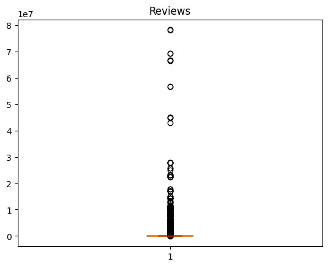

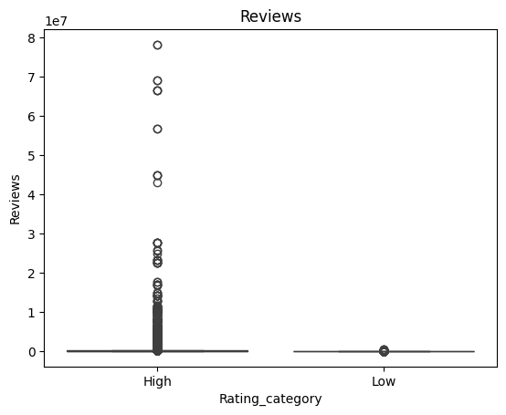

```python
## check the presence of outliers in the column
##BOXPLOT is used to check outliers
## Matplotlib
plt.boxplot(df['Reviews'])
plt.title("Reviews")
plt.show()
## Seaborn
sns.boxplot(x = "Rating_category", y = "Reviews", data=df)
plt.title("Reviews")
plt.show()
```

```python
## handle the outliers using a transformation approach.(Hint: Use log transformation)
df['Reviews_log'] = np.log(df['Reviews'])
df
```

|  | App | Category | Rating | Reviews | Size | Installs | Type | Price | Content Rating | Genres | Last Updated | Current Ver | Android Ver | Rating_category | Reviews_log |
| --- | --- | --- | --- | --- | --- | --- | --- | --- | --- | --- | --- | --- | --- | --- | --- |
| 0 | Photo Editor & Candy Camera & Grid & ScrapBook | ART_AND_DESIGN | 4.1 | 159 | 19M | 10,000+ | Free | 0 | Everyone | Art & Design | January 7, 2018 | 1.0.0 | 4.0.3 and up | High | 5.068904 |
| 1 | Coloring book moana | ART_AND_DESIGN | 3.9 | 967 | 14M | 500,000+ | Free | 0 | Everyone | Art & Design;Pretend Play | January 15, 2018 | 2.0.0 | 4.0.3 and up | High | 6.874198 |
| 2 | U Launcher Lite – FREE Live Cool Themes, Hide ... | ART_AND_DESIGN | 4.7 | 87510 | 8.7M | 5,000,000+ | Free | 0 | Everyone | Art & Design | August 1, 2018 | 1.2.4 | 4.0.3 and up | High | 11.379508 |
| 3 | Sketch - Draw & Paint | ART_AND_DESIGN | 4.5 | 215644 | 25M | 50,000,000+ | Free | 0 | Teen | Art & Design | June 8, 2018 | Varies with device | 4.2 and up | High | 12.281384 |
| 4 | Pixel Draw - Number Art Coloring Book | ART_AND_DESIGN | 4.3 | 967 | 2.8M | 100,000+ | Free | 0 | Everyone | Art & Design;Creativity | June 20, 2018 | 1.1 | 4.4 and up | High | 6.874198 |
| ... | ... | ... | ... | ... | ... | ... | ... | ... | ... | ... | ... | ... | ... | ... | ... |
| 10834 | FR Calculator | FAMILY | 4.0 | 7 | 2.6M | 500+ | Free | 0 | Everyone | Education | June 18, 2017 | 1.0.0 | 4.1 and up | High | 1.945910 |
| 10836 | Sya9a Maroc - FR | FAMILY | 4.5 | 38 | 53M | 5,000+ | Free | 0 | Everyone | Education | July 25, 2017 | 1.48 | 4.1 and up | High | 3.637586 |
| 10837 | Fr. Mike Schmitz Audio Teachings | FAMILY | 5.0 | 4 | 3.6M | 100+ | Free | 0 | Everyone | Education | July 6, 2018 | 1.0 | 4.1 and up | High | 1.386294 |
| 10839 | The SCP Foundation DB fr nn5n | BOOKS_AND_REFERENCE | 4.5 | 114 | Varies with device | 1,000+ | Free | 0 | Mature 17+ | Books & Reference | January 19, 2015 | Varies with device | Varies with device | High | 4.736198 |
| 10840 | iHoroscope - 2018 Daily Horoscope & Astrology | LIFESTYLE | 4.5 | 398307 | 19M | 10,000,000+ | Free | 0 | Everyone | Lifestyle | July 25, 2018 | Varies with device | Varies with device | High | 12.894978 |

8886 rows × 15 columns

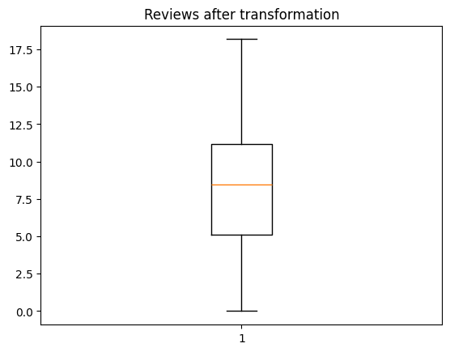

```python
## Checking is there any outliers after transformation
plt.boxplot(df['Reviews_log'])
plt.title("Reviews after transformation")
plt.show()
```

**Q9. The column 'Size' contains alphanumeric values, treat the non numeric data and convert the column into suitable data type. (hint: Replace M with 1 million and K with 1 thousand, and drop the entries where size='Varies with device')**

```python
a = df['Size'].dtype
a
```

```
dtype('O')
```

```python
## Convert the size column to string
df['Size'].astype(str)
```

|  | Size |
| --- | --- |
| 0 | 19M |
| 1 | 14M |
| 2 | 8.7M |
| 3 | 25M |
| 4 | 2.8M |
| ... | ... |
| 10834 | 2.6M |
| 10836 | 53M |
| 10837 | 3.6M |
| 10839 | Varies with device |
| 10840 | 19M |

8886 rows × 1 columns

**dtype:** object

```python
a = df['Size'].dtype
a
```

```
dtype('O')
```

```python
## removing the "varies with device" entries from size column
df = df[df['Size'] != 'Varies with device'] ## NaN is the invalid category.
df
```

|  | App | Category | Rating | Reviews | Size | Installs | Type | Price | Content Rating | Genres | Last Updated | Current Ver | Android Ver | Rating_category | Reviews_log |
| --- | --- | --- | --- | --- | --- | --- | --- | --- | --- | --- | --- | --- | --- | --- | --- |
| 0 | Photo Editor & Candy Camera & Grid & ScrapBook | ART_AND_DESIGN | 4.1 | 159 | 19M | 10,000+ | Free | 0 | Everyone | Art & Design | January 7, 2018 | 1.0.0 | 4.0.3 and up | High | 5.068904 |
| 1 | Coloring book moana | ART_AND_DESIGN | 3.9 | 967 | 14M | 500,000+ | Free | 0 | Everyone | Art & Design;Pretend Play | January 15, 2018 | 2.0.0 | 4.0.3 and up | High | 6.874198 |
| 2 | U Launcher Lite – FREE Live Cool Themes, Hide ... | ART_AND_DESIGN | 4.7 | 87510 | 8.7M | 5,000,000+ | Free | 0 | Everyone | Art & Design | August 1, 2018 | 1.2.4 | 4.0.3 and up | High | 11.379508 |
| 3 | Sketch - Draw & Paint | ART_AND_DESIGN | 4.5 | 215644 | 25M | 50,000,000+ | Free | 0 | Teen | Art & Design | June 8, 2018 | Varies with device | 4.2 and up | High | 12.281384 |
| 4 | Pixel Draw - Number Art Coloring Book | ART_AND_DESIGN | 4.3 | 967 | 2.8M | 100,000+ | Free | 0 | Everyone | Art & Design;Creativity | June 20, 2018 | 1.1 | 4.4 and up | High | 6.874198 |
| ... | ... | ... | ... | ... | ... | ... | ... | ... | ... | ... | ... | ... | ... | ... | ... |
| 10833 | Chemin (fr) | BOOKS_AND_REFERENCE | 4.8 | 44 | 619k | 1,000+ | Free | 0 | Everyone | Books & Reference | March 23, 2014 | 0.8 | 2.2 and up | High | 3.784190 |
| 10834 | FR Calculator | FAMILY | 4.0 | 7 | 2.6M | 500+ | Free | 0 | Everyone | Education | June 18, 2017 | 1.0.0 | 4.1 and up | High | 1.945910 |
| 10836 | Sya9a Maroc - FR | FAMILY | 4.5 | 38 | 53M | 5,000+ | Free | 0 | Everyone | Education | July 25, 2017 | 1.48 | 4.1 and up | High | 3.637586 |
| 10837 | Fr. Mike Schmitz Audio Teachings | FAMILY | 5.0 | 4 | 3.6M | 100+ | Free | 0 | Everyone | Education | July 6, 2018 | 1.0 | 4.1 and up | High | 1.386294 |
| 10840 | iHoroscope - 2018 Daily Horoscope & Astrology | LIFESTYLE | 4.5 | 398307 | 19M | 10,000,000+ | Free | 0 | Everyone | Lifestyle | July 25, 2018 | Varies with device | Varies with device | High | 12.894978 |

7418 rows × 15 columns

```python
## Replace M with 1 million and K with 1 thousand
df['Size'] = df['Size'].str.replace('k','000')
df['Size'] = df['Size'].str.replace('M','000000')
df
```

|  | App | Category | Rating | Reviews | Size | Installs | Type | Price | Content Rating | Genres | Last Updated | Current Ver | Android Ver | Rating_category | Reviews_log |
| --- | --- | --- | --- | --- | --- | --- | --- | --- | --- | --- | --- | --- | --- | --- | --- |
| 0 | Photo Editor & Candy Camera & Grid & ScrapBook | ART_AND_DESIGN | 4.1 | 159 | 19000000 | 10,000+ | Free | 0 | Everyone | Art & Design | January 7, 2018 | 1.0.0 | 4.0.3 and up | High | 5.068904 |
| 1 | Coloring book moana | ART_AND_DESIGN | 3.9 | 967 | 14000000 | 500,000+ | Free | 0 | Everyone | Art & Design;Pretend Play | January 15, 2018 | 2.0.0 | 4.0.3 and up | High | 6.874198 |
| 2 | U Launcher Lite – FREE Live Cool Themes, Hide ... | ART_AND_DESIGN | 4.7 | 87510 | 8.7000000 | 5,000,000+ | Free | 0 | Everyone | Art & Design | August 1, 2018 | 1.2.4 | 4.0.3 and up | High | 11.379508 |
| 3 | Sketch - Draw & Paint | ART_AND_DESIGN | 4.5 | 215644 | 25000000 | 50,000,000+ | Free | 0 | Teen | Art & Design | June 8, 2018 | Varies with device | 4.2 and up | High | 12.281384 |
| 4 | Pixel Draw - Number Art Coloring Book | ART_AND_DESIGN | 4.3 | 967 | 2.8000000 | 100,000+ | Free | 0 | Everyone | Art & Design;Creativity | June 20, 2018 | 1.1 | 4.4 and up | High | 6.874198 |
| ... | ... | ... | ... | ... | ... | ... | ... | ... | ... | ... | ... | ... | ... | ... | ... |
| 10833 | Chemin (fr) | BOOKS_AND_REFERENCE | 4.8 | 44 | 619000 | 1,000+ | Free | 0 | Everyone | Books & Reference | March 23, 2014 | 0.8 | 2.2 and up | High | 3.784190 |
| 10834 | FR Calculator | FAMILY | 4.0 | 7 | 2.6000000 | 500+ | Free | 0 | Everyone | Education | June 18, 2017 | 1.0.0 | 4.1 and up | High | 1.945910 |
| 10836 | Sya9a Maroc - FR | FAMILY | 4.5 | 38 | 53000000 | 5,000+ | Free | 0 | Everyone | Education | July 25, 2017 | 1.48 | 4.1 and up | High | 3.637586 |
| 10837 | Fr. Mike Schmitz Audio Teachings | FAMILY | 5.0 | 4 | 3.6000000 | 100+ | Free | 0 | Everyone | Education | July 6, 2018 | 1.0 | 4.1 and up | High | 1.386294 |
| 10840 | iHoroscope - 2018 Daily Horoscope & Astrology | LIFESTYLE | 4.5 | 398307 | 19000000 | 10,000,000+ | Free | 0 | Everyone | Lifestyle | July 25, 2018 | Varies with device | Varies with device | High | 12.894978 |

7418 rows × 15 columns

**Q10. Check the column 'Installs', treat the unwanted characters and convert the column into a suitable data type.**

```python
df['Installs'].unique()
```

```
array(['10,000+', '500,000+', '5,000,000+', '50,000,000+', '100,000+',
       '50,000+', '1,000,000+', '10,000,000+', '5,000+', '100,000,000+',
       '1,000+', '500,000,000+', '100+', '500+', '10+', '1,000,000,000+',
       '5+', '50+', '1+'], dtype=object)
```

```python
a = df['Installs'].dtype
a
```

```
dtype('O')
```

```python
## Convert the Installs column to string
df['Installs'].astype(str)
```

|  | Installs |
| --- | --- |
| 0 | 10,000+ |
| 1 | 500,000+ |
| 2 | 5,000,000+ |
| 3 | 50,000,000+ |
| 4 | 100,000+ |
| ... | ... |
| 10833 | 1,000+ |
| 10834 | 500+ |
| 10836 | 5,000+ |
| 10837 | 100+ |
| 10840 | 10,000,000+ |

7418 rows × 1 columns

**dtype:** object

```python
## treat the unwanted characters (i.e '+' & ',')
df['Installs'] = df['Installs'].str.replace('+','')
df['Installs'] = df['Installs'].str.replace(',','')
df
```

|  | App | Category | Rating | Reviews | Size | Installs | Type | Price | Content Rating | Genres | Last Updated | Current Ver | Android Ver | Rating_category | Reviews_log |
| --- | --- | --- | --- | --- | --- | --- | --- | --- | --- | --- | --- | --- | --- | --- | --- |
| 0 | Photo Editor & Candy Camera & Grid & ScrapBook | ART_AND_DESIGN | 4.1 | 159 | 19000000 | 10000 | Free | 0 | Everyone | Art & Design | January 7, 2018 | 1.0.0 | 4.0.3 and up | High | 5.068904 |
| 1 | Coloring book moana | ART_AND_DESIGN | 3.9 | 967 | 14000000 | 500000 | Free | 0 | Everyone | Art & Design;Pretend Play | January 15, 2018 | 2.0.0 | 4.0.3 and up | High | 6.874198 |
| 2 | U Launcher Lite – FREE Live Cool Themes, Hide ... | ART_AND_DESIGN | 4.7 | 87510 | 8.7000000 | 5000000 | Free | 0 | Everyone | Art & Design | August 1, 2018 | 1.2.4 | 4.0.3 and up | High | 11.379508 |
| 3 | Sketch - Draw & Paint | ART_AND_DESIGN | 4.5 | 215644 | 25000000 | 50000000 | Free | 0 | Teen | Art & Design | June 8, 2018 | Varies with device | 4.2 and up | High | 12.281384 |
| 4 | Pixel Draw - Number Art Coloring Book | ART_AND_DESIGN | 4.3 | 967 | 2.8000000 | 100000 | Free | 0 | Everyone | Art & Design;Creativity | June 20, 2018 | 1.1 | 4.4 and up | High | 6.874198 |
| ... | ... | ... | ... | ... | ... | ... | ... | ... | ... | ... | ... | ... | ... | ... | ... |
| 10833 | Chemin (fr) | BOOKS_AND_REFERENCE | 4.8 | 44 | 619000 | 1000 | Free | 0 | Everyone | Books & Reference | March 23, 2014 | 0.8 | 2.2 and up | High | 3.784190 |
| 10834 | FR Calculator | FAMILY | 4.0 | 7 | 2.6000000 | 500 | Free | 0 | Everyone | Education | June 18, 2017 | 1.0.0 | 4.1 and up | High | 1.945910 |
| 10836 | Sya9a Maroc - FR | FAMILY | 4.5 | 38 | 53000000 | 5000 | Free | 0 | Everyone | Education | July 25, 2017 | 1.48 | 4.1 and up | High | 3.637586 |
| 10837 | Fr. Mike Schmitz Audio Teachings | FAMILY | 5.0 | 4 | 3.6000000 | 100 | Free | 0 | Everyone | Education | July 6, 2018 | 1.0 | 4.1 and up | High | 1.386294 |
| 10840 | iHoroscope - 2018 Daily Horoscope & Astrology | LIFESTYLE | 4.5 | 398307 | 19000000 | 10000000 | Free | 0 | Everyone | Lifestyle | July 25, 2018 | Varies with device | Varies with device | High | 12.894978 |

7418 rows × 15 columns

```python
## convert the column into a suitable data type.
df['Installs'] = pd.to_numeric(df['Installs'])
df['Installs'].dtype ## Verifying the datatype after converting to suitable datatype
```

```
dtype('int64')
```

**Q11. Check the column 'Price', remove the unwanted characters and convert the column into a suitable data type.**

```python
df['Price'].unique()
```

```
array(['0', '$4.99', '$6.99', '$7.99', '$3.99', '$5.99', '$2.99', '$1.99',
       '$9.99', '$0.99', '$9.00', '$5.49', '$10.00', '$24.99', '$11.99',
       '$79.99', '$16.99', '$14.99', '$29.99', '$12.99', '$3.49',
       '$10.99', '$7.49', '$1.50', '$19.99', '$15.99', '$33.99', '$39.99',
       '$2.49', '$4.49', '$1.70', '$1.49', '$3.88', '$399.99', '$17.99',
       '$400.00', '$3.02', '$1.76', '$4.84', '$4.77', '$1.61', '$1.59',
       '$6.49', '$1.29', '$299.99', '$379.99', '$37.99', '$18.99',
       '$389.99', '$8.49', '$1.75', '$14.00', '$2.00', '$3.08', '$2.59',
       '$19.40', '$15.46', '$8.99', '$3.04', '$13.99', '$4.29', '$3.28',
       '$4.60', '$1.00', '$2.90', '$1.97', '$2.56', '$1.20'], dtype=object)
```

```python
df['Price'].dtype
df['Price'].astype(str)
```

|  | Price |
| --- | --- |
| 0 | 0 |
| 1 | 0 |
| 2 | 0 |
| 3 | 0 |
| 4 | 0 |
| ... | ... |
| 10833 | 0 |
| 10834 | 0 |
| 10836 | 0 |
| 10837 | 0 |
| 10840 | 0 |

7418 rows × 1 columns

**dtype:** object

```python
## treat the unwanted characters (i.e '$')
df['Price'] = df['Price'].str.replace('$','')
df
```

|  | App | Category | Rating | Reviews | Size | Installs | Type | Price | Content Rating | Genres | Last Updated | Current Ver | Android Ver | Rating_category | Reviews_log |
| --- | --- | --- | --- | --- | --- | --- | --- | --- | --- | --- | --- | --- | --- | --- | --- |
| 0 | Photo Editor & Candy Camera & Grid & ScrapBook | ART_AND_DESIGN | 4.1 | 159 | 19000000 | 10000 | Free | 0 | Everyone | Art & Design | January 7, 2018 | 1.0.0 | 4.0.3 and up | High | 5.068904 |
| 1 | Coloring book moana | ART_AND_DESIGN | 3.9 | 967 | 14000000 | 500000 | Free | 0 | Everyone | Art & Design;Pretend Play | January 15, 2018 | 2.0.0 | 4.0.3 and up | High | 6.874198 |
| 2 | U Launcher Lite – FREE Live Cool Themes, Hide ... | ART_AND_DESIGN | 4.7 | 87510 | 8.7000000 | 5000000 | Free | 0 | Everyone | Art & Design | August 1, 2018 | 1.2.4 | 4.0.3 and up | High | 11.379508 |
| 3 | Sketch - Draw & Paint | ART_AND_DESIGN | 4.5 | 215644 | 25000000 | 50000000 | Free | 0 | Teen | Art & Design | June 8, 2018 | Varies with device | 4.2 and up | High | 12.281384 |
| 4 | Pixel Draw - Number Art Coloring Book | ART_AND_DESIGN | 4.3 | 967 | 2.8000000 | 100000 | Free | 0 | Everyone | Art & Design;Creativity | June 20, 2018 | 1.1 | 4.4 and up | High | 6.874198 |
| ... | ... | ... | ... | ... | ... | ... | ... | ... | ... | ... | ... | ... | ... | ... | ... |
| 10833 | Chemin (fr) | BOOKS_AND_REFERENCE | 4.8 | 44 | 619000 | 1000 | Free | 0 | Everyone | Books & Reference | March 23, 2014 | 0.8 | 2.2 and up | High | 3.784190 |
| 10834 | FR Calculator | FAMILY | 4.0 | 7 | 2.6000000 | 500 | Free | 0 | Everyone | Education | June 18, 2017 | 1.0.0 | 4.1 and up | High | 1.945910 |
| 10836 | Sya9a Maroc - FR | FAMILY | 4.5 | 38 | 53000000 | 5000 | Free | 0 | Everyone | Education | July 25, 2017 | 1.48 | 4.1 and up | High | 3.637586 |
| 10837 | Fr. Mike Schmitz Audio Teachings | FAMILY | 5.0 | 4 | 3.6000000 | 100 | Free | 0 | Everyone | Education | July 6, 2018 | 1.0 | 4.1 and up | High | 1.386294 |
| 10840 | iHoroscope - 2018 Daily Horoscope & Astrology | LIFESTYLE | 4.5 | 398307 | 19000000 | 10000000 | Free | 0 | Everyone | Lifestyle | July 25, 2018 | Varies with device | Varies with device | High | 12.894978 |

7418 rows × 15 columns

```python
## convert the column into a suitable data type.
df['Price'] = df['Price'].astype(float)
df['Price'].dtype ## Verifying the datatype after converting to suitable datatype
```

```
dtype('float64')
```

**Q12. Drop the columns which you think redundant for the analysis.(suggestion: drop column 'rating', since we created a new feature from it (i.e. rating_category) and the columns 'App', 'Rating' ,'Genres','Last Updated', 'Current Ver','Android Ver' columns since which are redundant for our analysis)**

```python
df.drop(['Genres','Last Updated','Current Ver','Android Ver'], axis=1, inplace = True)
df
```

|  | App | Category | Rating | Reviews | Size | Installs | Type | Price | Content Rating | Rating_category | Reviews_log |
| --- | --- | --- | --- | --- | --- | --- | --- | --- | --- | --- | --- |
| 0 | Photo Editor & Candy Camera & Grid & ScrapBook | ART_AND_DESIGN | 4.1 | 159 | 19000000 | 10000 | Free | 0.0 | Everyone | High | 5.068904 |
| 1 | Coloring book moana | ART_AND_DESIGN | 3.9 | 967 | 14000000 | 500000 | Free | 0.0 | Everyone | High | 6.874198 |
| 2 | U Launcher Lite – FREE Live Cool Themes, Hide ... | ART_AND_DESIGN | 4.7 | 87510 | 8.7000000 | 5000000 | Free | 0.0 | Everyone | High | 11.379508 |
| 3 | Sketch - Draw & Paint | ART_AND_DESIGN | 4.5 | 215644 | 25000000 | 50000000 | Free | 0.0 | Teen | High | 12.281384 |
| 4 | Pixel Draw - Number Art Coloring Book | ART_AND_DESIGN | 4.3 | 967 | 2.8000000 | 100000 | Free | 0.0 | Everyone | High | 6.874198 |
| ... | ... | ... | ... | ... | ... | ... | ... | ... | ... | ... | ... |
| 10833 | Chemin (fr) | BOOKS_AND_REFERENCE | 4.8 | 44 | 619000 | 1000 | Free | 0.0 | Everyone | High | 3.784190 |
| 10834 | FR Calculator | FAMILY | 4.0 | 7 | 2.6000000 | 500 | Free | 0.0 | Everyone | High | 1.945910 |
| 10836 | Sya9a Maroc - FR | FAMILY | 4.5 | 38 | 53000000 | 5000 | Free | 0.0 | Everyone | High | 3.637586 |
| 10837 | Fr. Mike Schmitz Audio Teachings | FAMILY | 5.0 | 4 | 3.6000000 | 100 | Free | 0.0 | Everyone | High | 1.386294 |
| 10840 | iHoroscope - 2018 Daily Horoscope & Astrology | LIFESTYLE | 4.5 | 398307 | 19000000 | 10000000 | Free | 0.0 | Everyone | High | 12.894978 |

7418 rows × 11 columns

**Q13. Encode the categorical columns.**

```python
from sklearn.preprocessing import LabelEncoder ## import labelEncoder library
le = LabelEncoder() ## instance of labelEncoder
df.iloc[:, [0,1,6,8,9]] = df.iloc[:, [0,1,6,8,9]].apply(le.fit_transform) ## Encoding categorical columns
df.iloc[:, [0,1,6,8,9]].head() ## Checking the colums after labelEncoding
```

[output not shown]

**Q14. Segregate the target and independent features (Hint: Use Rating_category as the target)**

```python
## Storing the target column in the y variable and rest columns in the x variable.
x = df.drop('Rating_category', axis = 1)
x
```

[output not shown]

7418 rows × 10 columns

```python
## Storing the target column in the y variable and rest columns in the x variable.
y = df['Rating_category']
y
```

|  | Rating_category |
| --- | --- |
| 0 | 0 |
| 1 | 0 |
| 2 | 0 |
| 3 | 0 |
| 4 | 0 |
| ... | ... |
| 10833 | 0 |
| 10834 | 0 |
| 10836 | 0 |
| 10837 | 0 |
| 10840 | 0 |

7418 rows × 1 columns

**dtype:** object

**Q15. Split the dataset into train and test.**

```python
from sklearn.model_selection import train_test_split
x_train, x_test, y_train, y_test = train_test_split(x, y, test_size = 0.30)
print(x_train.shape, x_test.shape)
print(y_train.shape, y_test.shape)
```

```
(5192, 10) (2226, 10)
(5192,) (2226,)
```

**Q16. Standardize the data, so that the values are within a particular range.**

```python
from sklearn.preprocessing import StandardScaler ## import StandarScaler library
S = StandardScaler() ## Create an object for scaling
x_train = S.fit_transform(x_train) ## fit_transform() calculates the mean and standard deviation from the training data
x_test = S.transform(x_test) ## transform() applies the same scaling learned from the training data to the test data.
df
```

[output not shown]

7418 rows × 11 columns

Standardization is applied only to the independent variables (X) to bring them to the same scale. The target variable (y) is not standardized because it represents the output labels that the model needs to predict. In classification problems, modifying the target values would change their meaning